# Stats 506, F20, Group Project

Your Name, email@umich.edu

November 05, 2020

# 1 Brief Introduction to Geographic Vector Data

*This section will use some codes to show plots and vectors, but will not be repeated in Python or SAS, because these are just for explanation and not directly related to our examples.*

## 1.1 Understanding Polygons

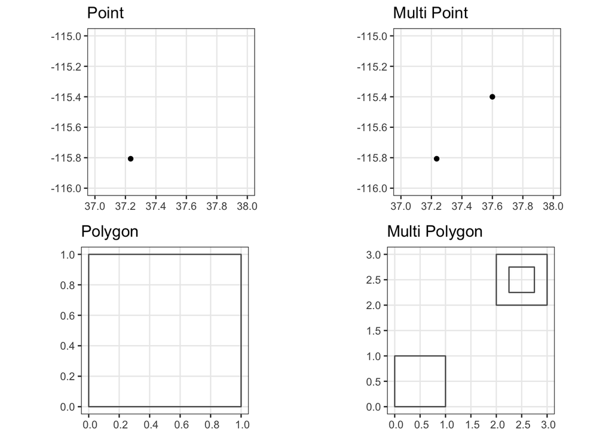

State coordinates are recorded as *multipolygons* due to the presence of some disjoints.

The only difference from previous examples is that the Cartesian coordinate system has now been changed to a geographic coordinate system consisting of latitude and longitude. With the International Date Line as an edge, the x-axis has a range of -180 to 180 degrees from west to east, and the y-axis has a range of -90 to 90 degrees from south to north. This system may be very intuitive.

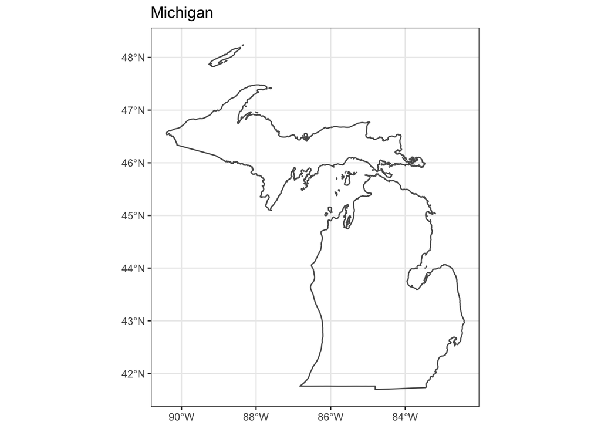

## 1.2 Understanding Geographic Coodinate System

There are not many things you have to worry about when drawing a map, but it should be noted that geographic coordinate systems are actually quite complex. It is difficult to describe the position on the Earth’s surface because the Earth is not exactly spherical. Also, the coordinates defined by angles (i.e., longitude and latitude) cannot be transformed into Cartesian coordinates without some distortion.

There are several different *Coordinate Reference Systems (CRSs)* available in the world. They approximate the Earth’s surface somehow and define the relationship between the geographic objects and the surface of the Earth. Since you cannot join multiple `shapefile` that are based on different CRSs, you should check what CRS your shapefile is based on and transform them if needed.

*Geographic CRSs* approximate the Earth’s surface by an ellipsoid shape and identify a location on the surface by using two angles, longitude and latitude. The most common *Geographic CRSs* include:

- *The North American Datum of 1983 (NAD 83)* is commonly used by U.S. federal agencies and is optimized for accuracy in the United States, Canada, Mexico, and Central America.
- *World Geodetic System of 1984 (WGS 84)* is commonly used by international organizations and uses the Earth’s center of gravity as a reference point. It is not optimized for any local region.

*Projected CRSs* refer to the coordinate systems used for 2-dimensional projection. When drawing a map, locations on the Earth’s surface must be projected onto a flat paper, display, etc., which may result in some distortion. In practice, we need to project a point defined in *Geographic CRSs* onto 2-dimensional x (east-west) axis and y (north-south) axis. There are many different projection methods available, and each has both strengths and weaknesses. You should carefully choose one for its intended purpose. The most common *Projected CRSs* include:

- *Mercator* draws a familiar rectangular map and can preserve local directions and shapes. However, it distorts distance and inflates the sizes of countries away from the equator.
- *Albers Equal Area* preserve accurate area measurement but distorts linear scale and shapes.

In this tutorial, we use `NAD 83` as our *Geographic CRS* and `Mercator` as our *Projected CRS*.

## 1.3 “Edge Case”: Object on the International Date Line

Another small issue is that although the boundaries are actually continuous on the Earth’s surface, some countries are divided by the International Date Line. For example, a part of Alaska exists exactly on the International Date Line. As a result, Alaska is shown separately on the western-most and eastern-most sides of the world map.

Different software has different ways of dealing with this, but it is sometimes necessary to shift the entire coordinate system.

# 2 Prepare Geographic Vector Data to Display

The US Census Bureau provides free cartographic boundary data at the national, state, county, zip code and other levels. For this tutorial, we used the following state-level boundary data:

- `cb_2018_us_state_500k.zip`

We unzipped this compressed file and saved the entire contents into a subdirectory called `./maps`.

## 2.1 Software Requirements

### 2.1.1 R

```r
library(tidyverse) # Data handling
library(ggplot2) # Generating plots
library(ggpubr) # Helper functions for `ggplot2` e.g. multiple plots
library(sf) # handling shapefiles
```

### 2.1.2 Python

### 2.1.3 SAS

## 2.2 How to Handle Shapefiles

### 2.2.1 R

We can create a `sf` object by loading a shapefile using `read_sf`.

`read_sf` is an alias for `st_read`. `read_sf` returns a tibble rather than data.frame.

```r
# read shapefile
filename = "./maps/cb_2018_us_state_500k.shp"
sf_us = read_sf(filename)
```

We can see the resulting object is a tibble. Therefore, operations such as deleting certain states from the map can be easily performed using `dplyr`.

```r
head(sf_us, 5)
```

```
## Simple feature collection with 5 features and 9 fields
## geometry type:  MULTIPOLYGON
## dimension:      XY
## bbox:           xmin: -103.0026 ymin: 30.17394 xmax: -75.24227 ymax: 40.6388
## geographic CRS: NAD83
## # A tibble: 5 x 10
##   STATEFP STATENS AFFGEOID GEOID STUSPS NAME  LSAD    ALAND  AWATER
##   <chr>   <chr>   <chr>    <chr> <chr>  <chr> <chr>   <dbl>   <dbl>
## 1 28      017797… 0400000… 28    MS     Miss… 00    1.22e11 3.93e 9
## 2 37      010276… 0400000… 37    NC     Nort… 00    1.26e11 1.35e10
## 3 40      011028… 0400000… 40    OK     Okla… 00    1.78e11 3.37e 9
## 4 51      017798… 0400000… 51    VA     Virg… 00    1.02e11 8.53e 9
## 5 54      017798… 0400000… 54    WV     West… 00    6.23e10 4.89e 8
## # … with 1 more variable: geometry <MULTIPOLYGON [°]>
```

### 2.2.2 Python

### 2.2.3 SAS

## 2.3 How to Draw a US Map

### 2.3.1 R

You can easily draw state boundaries recorded as multi-polygons by passing `sf` objects to `ggplot2`.

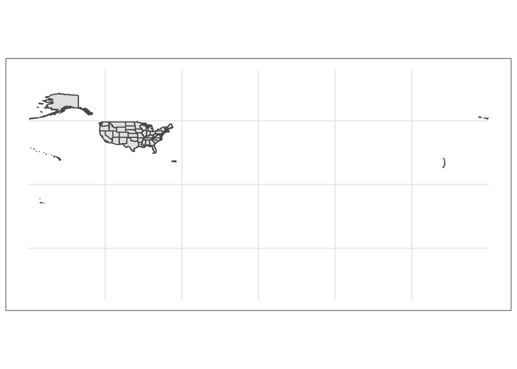

```r
sf_us %>%
  ggplot() +
  geom_sf() +
  coord_sf(xlim = c(-180, 180), ylim = c(-90, 90)) +
  theme_bw()
```

The Census Bureau’s shapefiles also include coordinates for Alaska, Hawaii, or other distant territories, so they are not displayed at the scale we desire. The easiest solution is to drop the rows that contain these off-mainland states and territories.

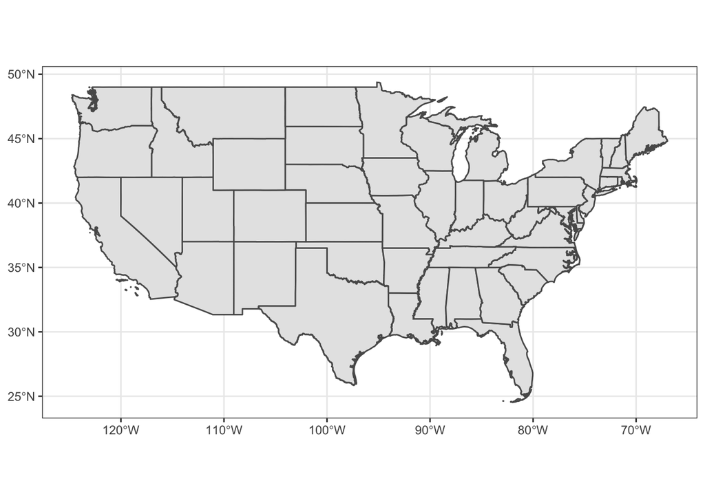

```r
sf_us %>%
  filter( !(NAME %in% c("Alaska",
                        "Hawaii",
                        "Puerto Rico",
                        "Guam",
                        "United States Virgin Islands",
                        "Commonwealth of the Northern Mariana Islands",
                        "American Samoa")) ) %>%
  ggplot() +
  geom_sf() +
  coord_sf() +
  theme_bw()
```

However, we want to include Alaska and Hawaii because our purpose is to make a state-by-state comparison. For practical purposes, scaled Alaska and Hawaii are typically shown as annotations under southern California. This can be accomplished manually by scaling and shifting the original objects. We take out only Alaska and Hawaii, apply an affine transformation to scale and shift them, and then put them back into the original tibble.

But before that, since Alaska is on the date line and divided into two pieces as mentioned above, we shift all coordinates of the United States below 0 (-180-0 degree in longitude) to 180-360 degrees. This can be achieved by applying `st_shift_longitude()` to `geometry` column of `sf` objects.

```r
# Change to 0-360 system, with Alaska and Hawaii retained
sf_us_360 = sf_us %>%
  filter( !(NAME %in% c("Puerto Rico",
                        "Guam",
                        "United States Virgin Islands",
                        "Commonwealth of the Northern Mariana Islands",
                        "American Samoa")) ) %>%
  mutate(geometry = st_shift_longitude(geometry))
```

$$f(x) = xA + b$$

```r
affine_trans = function(sf_obj, scale, shift_lon_lat) {
  # Scale sf geometries around their original centroid, and shift it
  # horizontally and/or vertically.
  # Inputs:
  #   sf_obj - simple features you want to scale/shift
  #   scale - numeric value of a factor to be used for scaling up or down
  #   shift_lon_lat - numeric vector indicating amount of shift e.g. c(1,1)
  # Output: sf_obj - updated simple features
  geo = st_geometry(sf_obj)
  st_geometry(sf_obj) = ( (geo - st_centroid(geo)) * scale
                           + shift_lon_lat + st_centroid(geo) )
  return(sf_obj)
}
```

```r
# Extract, scale, and shift Alaska
alaska = sf_us_360 %>%
  filter(NAME == "Alaska") %>%
  affine_trans(scale = .3, shift_lon_lat = c(36, -38))
# Extract, scale, and shift Hawaii
hawaii = sf_us_360 %>%
  filter(NAME == "Hawaii") %>%
  affine_trans(scale = .3, shift_lon_lat = c(53, 5))
# Bind back into single object
sf_us_shifted = sf_us_360 %>%
  filter( !(NAME %in% c("Alaska", "Hawaii")) ) %>%
  bind_rows(alaska, hawaii)
```

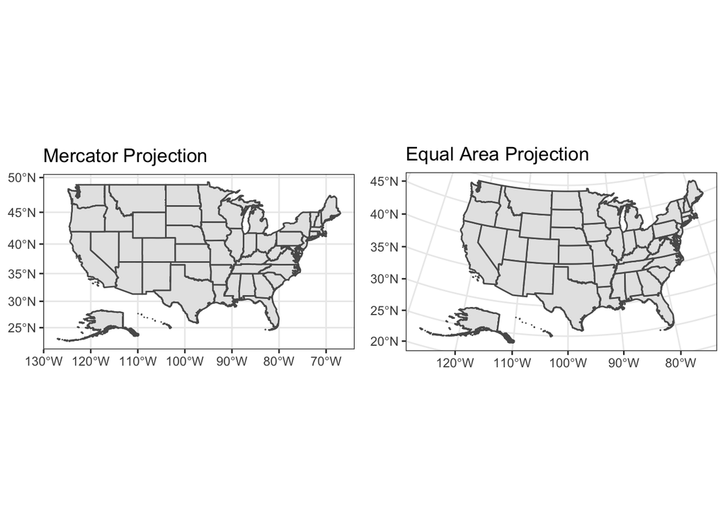

```r
# Mercator Projection
mercator = sf_us_shifted %>%
  ggplot() +
  geom_sf() +
  coord_sf(crs = "+proj=merc") +
  theme_bw() +
  ggtitle("Mercator Projection")
# Equal Area Projection
equal_area = sf_us_shifted %>%
  ggplot() +
  geom_sf() +
  coord_sf(crs = "+proj=aea +lat_1=25 +lat_2=50 +lon_0=-100") +
  theme_bw() +
  ggtitle("Equal Area Projection")

# Show plot
ggarrange(mercator, equal_area, ncol = 2)
```

The final map we will use in the later sections is the one with Alaska and Hawaii, projected by Mercator CRS.

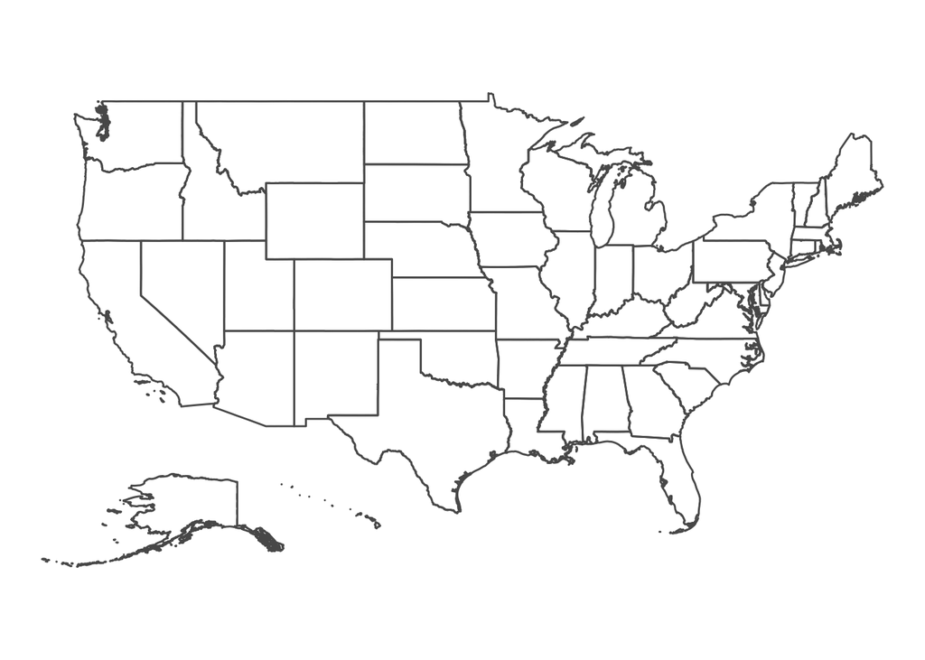

```r
sf_us_shifted %>%
  ggplot() +
  geom_sf(fill = NA) +
  coord_sf(crs = "+proj=merc") +
  theme_void() # hide coordinates and grid line for visibility
```

### 2.3.3 SAS

# 3 Prepare Count Data to Display

In this tutorial, we used the following variables in the state-level data.

- `state` - two-letter abbreviation for the state or territory.
- `date` - date formatted as `yyyy-mm-dd`
- `positiveIncrease` - daily increase in total number of confirmed plus probable cases of COVID-19

For more information on this dataset, including definitions of variable names, see [Data Definitions](https://covidtracking.com/about-data/data-definitions) provided by The COVID Tracking Project.

## 3.1 Software Requirements

### 3.1.1 R

```r
# Same as the previous sections
library(tidyverse)
# New in this section
library(lubridate) # Aggregation by Datetime
```

### 3.1.2 Python

### 3.1.3 SAS

## 3.2 Merge COVID-19 Count with Geographic Data

### 3.2.1 R

```r
# Download up-to-date .csv
df_covid = read_csv(
  url("https://covidtracking.com/data/download/all-states-history.csv")
  )

# Select variables and delete territories
df_covid = df_covid %>%
  select(date, state, positiveIncrease) %>%
  filter( !(state %in% c("AS", "GU", "MP", "PR", "VI")) )
```

```r
# Aggregate by State and Quarter
df_state_q = df_covid %>%
  mutate(q = quarter(date, with_year = TRUE)) %>%
  group_by(q, state) %>%
  summarise(total_pos = sum(positiveIncrease)) %>%
  ungroup()

# Store maximum value for consistent plots for all quarters
max_positive = max(df_state_q$total_pos)

# Pivot to wide
df_state_q = df_state_q %>%
  pivot_wider(id_cols = state, names_from = q, values_from = total_pos)

#Show resulting data
df_state_q %>%
  head(5) %>%
  kable(format = 'html', escape = FALSE, align = 'c') %>%
  kable_paper("hover", full_width = TRUE)
```

| state | 2020.1 | 2020.2 | 2020.3 | 2020.4 |
| --- | --- | --- | --- | --- |
| AK | 119 | 821 | 7840 | 9080 |
| AL | 981 | 37064 | 116656 | 43076 |
| AR | 523 | 20254 | 62920 | 32115 |
| AZ | 1287 | 77926 | 139292 | 32126 |
| CA | 7429 | 221250 | 581893 | 129385 |

```r
# Merge with sf object
sf_merged = sf_us_shifted %>%
  left_join(df_state_q, by = c("STUSPS" = "state"))
```

### 3.2.2 Python

### 3.2.3 SAS

# 4 Generate Choropleth Maps

## 4.1 Software Requirements

### 4.1.1 R

```r
# Same as the previous sections
library(tidyverse); library(ggplot2)
# New in this section
library(scales) # determine breaks and labels for graphics
```

### 4.1.2 Python

### 4.1.3 SAS

## 4.2 Show Choropleth Maps for each Quarter in 2020

### 4.2.1 R

```r
draw_map_quarter = function(sf_obj, target_q, max_lim) {
  sf_obj %>%
    ggplot() +
    # Colored by total positives in the selected quarter
    geom_sf(color = NA, # make border lines white for aesthetics
            mapping = aes(fill = .data[[target_q]])) +
    coord_sf(crs = "+proj=merc") +
    theme(
    # Remove background
    panel.border = element_blank(),
    panel.grid.major = element_blank(),
    panel.grid.minor = element_blank(),
    panel.background = element_blank(),
    # Hide axis
    axis.line = element_blank(),
    axis.text = element_blank(),
    axis.ticks = element_blank(),
    # Adjust legend
    legend.title = element_blank(),
    legend.text = element_text(size = 8) ) +
    # Apply color scheme (red)
    scale_fill_distiller(palette = "Reds",
                         direction = +1, # more cases = darker color
                         limits = c(0, max_lim),
                         labels = comma) + # force all digits to be displayed
    # Adjust size of the color bar in the legend
    guides(fill = guide_colourbar(barwidth = 0.5, barheight = 10))
}
```

#### 4.2.1.1 First Quarter

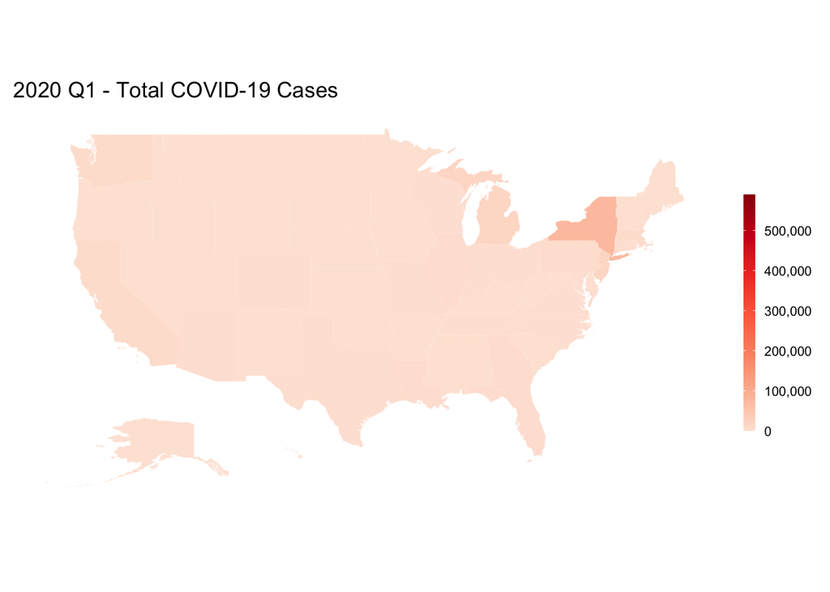

```r
# Generate choropleth for each quarter
draw_map_quarter(sf_merged, "2020.1", max_positive) +
  ggtitle("2020 Q1 - Total COVID-19 Cases")
```

#### 4.2.1.2 Second Quarter

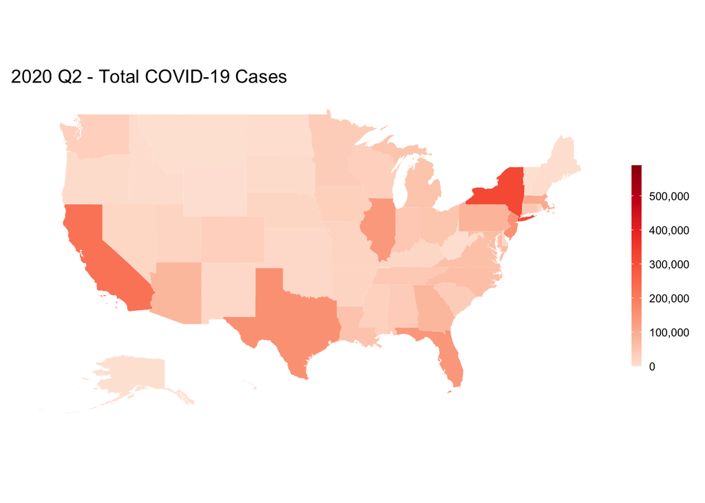

```r
draw_map_quarter(sf_merged, "2020.2", max_positive) +
  ggtitle("2020 Q2 - Total COVID-19 Cases")
```

#### 4.2.1.3 Third Quarter

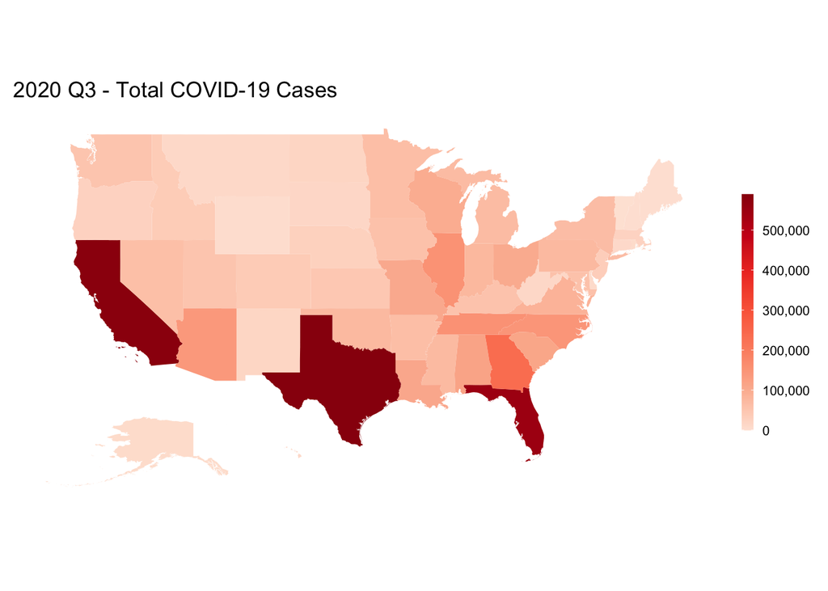

```r
draw_map_quarter(sf_merged, "2020.3", max_positive) +
  ggtitle("2020 Q3 - Total COVID-19 Cases")
```

#### 4.2.1.4 Fourth Quarter

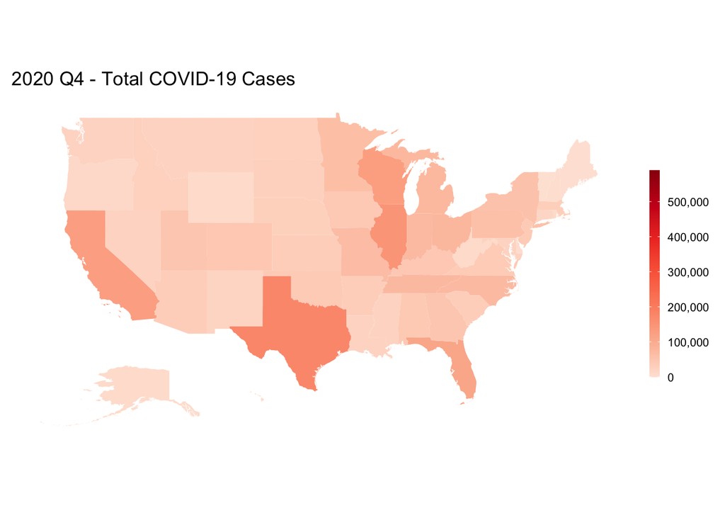

```r
draw_map_quarter(sf_merged, "2020.4", max_positive) +
  ggtitle("2020 Q4 - Total COVID-19 Cases")
```

### 4.2.2 Python

### 4.2.3 SAS